# Homework 07

STAT 432 · Python (numpy, pandas, scikit-learn, matplotlib). Seeds: Q3 = **432**, Q4 = **2026**.

## Question 1: LDA

### a. Estimated components

The data have *n* = 462 observations and 9 numeric predictors (`famhist` coded 1 = Absent, 2 = Present). Classes: `chd` = 0 (*n*<sub>0</sub> = 302) and `chd` = 1 (*n*<sub>1</sub> = 160).

**Priors** (class proportions): π̂<sub>0</sub> = 0.6537, π̂<sub>1</sub> = 0.3463.

**Class means** (2 × 9; rows are classes):

|  | sbp | tobacco | ldl | adiposity | famhist | typea | obesity | alcohol | age |
| --- | --- | --- | --- | --- | --- | --- | --- | --- | --- |
| chd = 0 | 135.460 | 2.635 | 4.344 | 23.969 | 1.318 | 52.368 | 25.737 | 15.931 | 38.854 |
| chd = 1 | 143.738 | 5.525 | 5.488 | 28.120 | 1.600 | 54.494 | 26.623 | 19.145 | 50.294 |

**Pooled covariance** Σ̂ = [Σ<sub>k</sub> Σ<sub>i:y<sub>i</sub>=k</sub> (x<sub>i</sub> − μ̂<sub>k</sub>)(x<sub>i</sub> − μ̂<sub>k</sub>)<sup>T</sup>] / (*n* − 2) = [Σ<sub>k</sub> Σ<sub>i:y<sub>i</sub>=k</sub> (x<sub>i</sub> − μ̂<sub>k</sub>)(x<sub>i</sub> − μ̂<sub>k</sub>)<sup>T</sup>] / 460 (9 × 9):

|  | sbp | tobacco | ldl | adiposity | famhist | typea | obesity | alcohol | age |
| --- | --- | --- | --- | --- | --- | --- | --- | --- | --- |
| sbp | 405.435 | 14.585 | 4.581 | 49.164 | 0.337 | -15.588 | 18.939 | 64.400 | 95.134 |
| tobacco | 14.585 | 19.243 | 0.763 | 7.538 | 0.016 | -2.057 | 1.833 | 20.517 | 22.765 |
| ldl | 4.581 | 0.763 | 4.001 | 6.033 | 0.092 | 0.345 | 2.660 | -2.533 | 6.479 |
| adiposity | 49.164 | 7.538 | 6.033 | 56.753 | 0.433 | -5.310 | 22.708 | 16.119 | 60.509 |
| famhist | 0.337 | 0.016 | 0.092 | 0.433 | 0.226 | 0.081 | 0.184 | 0.768 | 0.997 |
| typea | -15.588 | -2.057 | 0.345 | -5.310 | 0.081 | 95.566 | 2.640 | 7.960 | -20.278 |
| obesity | 18.939 | 1.833 | 2.660 | 22.708 | 0.184 | 2.640 | 17.615 | 4.689 | 15.697 |
| alcohol | 64.400 | 20.517 | -2.533 | 16.119 | 0.768 | 7.960 | 4.689 | 598.277 | 27.886 |
| age | 95.134 | 22.765 | 6.479 | 60.509 | 0.997 | -20.278 | 15.697 | 27.886 | 184.132 |

### b. In-sample predictions from hand-computed scores

Dimension check: **X** is 462×9, **y** has 462 entries, the mean matrix is 2×9, Σ̂ is 9×9, and the score matrix is 462×2 (one column per class). Each score is `x'Σ-1μk − ½μk'Σ-1μk + log πk`, and the predicted label is the class with the larger score.

|  | pred 0 | pred 1 |
| --- | --- | --- |
| obs 0 | 258 | 44 |
| obs 1 | 73 | 87 |

Training misclassification rate: (44 + 73)/462 = **0.2532**.

### c. Comparison with scikit-learn

`LinearDiscriminantAnalysis(solver="svd", priors=empirical priors)` gives the confusion matrix

|  | pred 0 | pred 1 |
| --- | --- | --- |
| obs 0 | 258 | 44 |
| obs 1 | 73 | 87 |

**Yes, the results match**: the predicted labels agree for 462 of 462 observations and the two confusion matrices are identical.

```
pi = np.array([(y==k).mean() for k in (0,1)])
mu = np.array([X[y==k].mean(0) for k in (0,1)])
S  = sum((X[y==k]-mu[k]).T @ (X[y==k]-mu[k]) for k in (0,1)) / (n-2)
Si = np.linalg.inv(S)
scores = X @ Si @ mu.T - 0.5*np.einsum("kp,pq,kq->k", mu, Si, mu) + np.log(pi)
pred = scores.argmax(1)
lda = LinearDiscriminantAnalysis(solver="svd", priors=pi).fit(X, y)
```

## Question 2: QDA and marginal screening

Training: 7291 digits; test: 2007 digits; 256 pixel predictors. Pixel variances are computed on the raw training pixels (no standardizing) and the same pixel indices are used on the test set. QDA is `QuadraticDiscriminantAnalysis(tol=1e-8)`.

### a. 40 highest-variance pixels

Test confusion matrix (observed in rows, predicted in columns; diagonal highlighted, off-diagonal counts of 10 or more in red):

| obs \ pred | 0 | 1 | 2 | 3 | 4 | 5 | 6 | 7 | 8 | 9 |
| --- | --- | --- | --- | --- | --- | --- | --- | --- | --- | --- |
| 0 | 319 | 0 | 24 | 6 | 2 | 2 | 1 | 0 | 5 | 0 |
| 1 | 0 | 238 | 5 | 0 | 11 | 0 | 7 | 0 | 3 | 0 |
| 2 | 8 | 0 | 168 | 8 | 8 | 3 | 0 | 0 | 3 | 0 |
| 3 | 5 | 0 | 4 | 128 | 0 | 14 | 0 | 0 | 15 | 0 |
| 4 | 0 | 2 | 13 | 1 | 150 | 1 | 0 | 1 | 7 | 25 |
| 5 | 12 | 0 | 3 | 5 | 1 | 131 | 0 | 0 | 6 | 2 |
| 6 | 0 | 0 | 8 | 0 | 1 | 8 | 148 | 0 | 5 | 0 |
| 7 | 1 | 0 | 6 | 1 | 6 | 0 | 0 | 124 | 2 | 7 |
| 8 | 1 | 0 | 10 | 12 | 3 | 2 | 0 | 0 | 137 | 1 |
| 9 | 0 | 0 | 1 | 2 | 7 | 1 | 1 | 4 | 9 | 152 |

**Test misclassification rate: 0.1555** (312 of 2007). Training error is 0.0834.

### b. Does the method work?

**Yes, reasonably well.** With all 256 pixels QDA cannot be fitted because the class covariance matrices are singular (ranks per class range from 125 to 256, mostly below 256, because many border pixels are almost constant and others are nearly collinear). With the 40 highest-variance pixels, each class has 542 to 1194 training images, which is comfortably larger than the 40 predictors required for a full-rank sample covariance matrix. The covariance matrices are therefore invertible (smallest class eigenvalue about 2.7e-07, small but positive), although estimating 820 covariance parameters per class is still statistically demanding. The test error of 15.5% is much better than chance (90%).

Caveats: the training error (8.3%) is about half the test error, which indicates overfitting from the 10 × 820 covariance parameters. The smallest eigenvalue is also close to the tolerance, so the fit is close to the edge of numerical stability. As a check, larger screened sets fail: 50, 60, 80 pixels give singular class covariances.

| Top-*m* pixels | Test error | Training error |
| --- | --- | --- |
| 5 | 0.4614 | 0.4285 |
| 10 | 0.3423 | 0.2888 |
| 15 | 0.2666 | 0.2112 |
| 20 | 0.2053 | 0.1483 |
| 30 | 0.1714 | 0.1030 |
| 40 | 0.1555 | 0.0834 |
| 50 | fails: singular class covariance | — |
| 60 | fails: singular class covariance | — |
| 80 | fails: singular class covariance | — |

Screening works because it keeps pixels that vary a lot (so each covariance matrix is well conditioned) while discarding the near-constant pixels that make the covariance matrices singular. The price is that low-variance pixels may still carry class information (an unbiased-but-lossy filter), and marginal variance does not look at the class labels at all.

### c. 10 highest-variance pixels

| obs \ pred | 0 | 1 | 2 | 3 | 4 | 5 | 6 | 7 | 8 | 9 |
| --- | --- | --- | --- | --- | --- | --- | --- | --- | --- | --- |
| 0 | 298 | 0 | 11 | 1 | 1 | 16 | 28 | 4 | 0 | 0 |
| 1 | 0 | 241 | 10 | 0 | 3 | 1 | 1 | 0 | 2 | 6 |
| 2 | 19 | 2 | 95 | 14 | 14 | 3 | 22 | 21 | 5 | 3 |
| 3 | 5 | 0 | 6 | 103 | 3 | 42 | 0 | 0 | 7 | 0 |
| 4 | 1 | 5 | 14 | 0 | 95 | 2 | 4 | 15 | 17 | 47 |
| 5 | 15 | 0 | 6 | 25 | 4 | 96 | 4 | 2 | 8 | 0 |
| 6 | 41 | 0 | 15 | 4 | 0 | 18 | 78 | 7 | 5 | 2 |
| 7 | 4 | 1 | 6 | 0 | 6 | 0 | 1 | 122 | 0 | 7 |
| 8 | 1 | 2 | 11 | 36 | 12 | 11 | 4 | 1 | 74 | 14 |
| 9 | 0 | 2 | 9 | 2 | 20 | 0 | 0 | 16 | 10 | 118 |

**Test misclassification rate: 0.3423** (vs. 0.1555 with 40 pixels); training error 0.2888. The 10-pixel model is much worse: the error more than doubles.

Why: with only 10 pixels QDA is very stable (smallest class eigenvalue about 2.4e-03, the train-test gap is only about 5 points, and both errors are high), but it is **biased**. Ten pixels cannot carry enough information to separate ten digit shapes, so the model underfits. The 40-pixel model adds a lot of discriminating information, and with about 550 to 1,200 images per class the added variance of estimating a 40×40 covariance matrix is worth paying. This is the bias-variance trade-off: the test error falls steadily from 5 to 40 pixels (see the sweep above) until the covariance estimates become singular at 50 pixels.

## Question 3: Compare LDA and QDA

**Seed:** `numpy.random.default_rng(432)` for part a, and `default_rng(433)` for part b. Each setting uses 100 training observations *per class* and 1,000 test observations per class (so 200 training and 2,000 test in total), equal priors, 10 covariates. LDA uses the pooled covariance matrix; QDA uses one covariance matrix per class.

### a. One dataset per ρ

| ρ | LDA test error | QDA test error | Better |
| --- | --- | --- | --- |
| 0 | 0.1710 | 0.2010 | LDA |
| 0.2 | 0.1715 | 0.1810 | LDA |
| 0.4 | 0.1575 | 0.1715 | LDA |
| 0.6 | 0.1535 | 0.1605 | LDA |
| 0.8 | 0.1815 | 0.1495 | QDA |
| 0.9 | 0.1815 | 0.1030 | QDA |

Each row is a single draw, so differences of about 0.01 to 0.02 are within noise; part b averages over repetitions.

### b. 50 repetitions per ρ

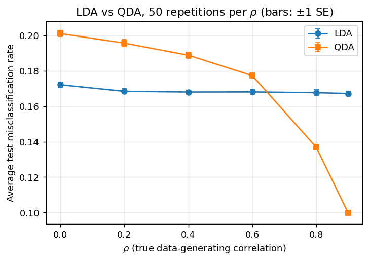

| ρ | LDA mean | LDA SE | QDA mean | QDA SE | Bayes error (Monte Carlo) |
| --- | --- | --- | --- | --- | --- |
| 0 | 0.1721 | 0.0016 | 0.2010 | 0.0018 | 0.1591 |
| 0.2 | 0.1684 | 0.0014 | 0.1956 | 0.0020 | 0.1575 |
| 0.4 | 0.1680 | 0.0012 | 0.1888 | 0.0016 | 0.1573 |
| 0.6 | 0.1681 | 0.0013 | 0.1773 | 0.0013 | 0.1472 |
| 0.8 | 0.1676 | 0.0016 | 0.1369 | 0.0013 | 0.1153 |
| 0.9 | 0.1672 | 0.0012 | 0.0997 | 0.0010 | 0.0836 |

### c. Interpretation

**Small ρ.** When ρ = 0 the two classes have identical covariance matrices (the identity), so the LDA assumption is exactly true. LDA is then the better method (about 0.172 vs. 0.201): it estimates one pooled covariance matrix, while QDA estimates two, and QDA pays extra variance for flexibility it does not need. The gap shrinks as ρ grows, and the curves cross between ρ = 0.6 and 0.8.

**Large ρ.** The two covariance matrices differ more and more (correlation +ρ vs. −ρ between X<sub>1</sub> and X<sub>2</sub>), and the optimal boundary is genuinely quadratic. LDA's error stays flat near 0.167: it only sees the mean shift in X<sub>1</sub>, and the information carried by the covariance difference is invisible to a linear rule with a pooled covariance. LDA is biased, but the bias does not change with ρ. QDA captures the structure, and its error falls to 0.100 at ρ = 0.9, close to the Bayes error of about 0.084.

**Bias-variance.** LDA has low variance (about 10 means per class plus 55 covariance parameters) and potentially high bias; QDA has low bias but higher variance (55 covariance parameters *per class*, estimated from only 100 observations per class). The better method depends on whether the bias saved by QDA exceeds the extra variance it costs, which depends on how different the true covariances are.

**The eight noise covariates.** They carry no class information, but the methods do not know that. Each noise variable adds a mean parameter and many covariance parameters that must be estimated from limited data, and these estimation errors enter the discriminant function. For QDA the effect is larger: going from 2 to 10 variables raises the number of covariance parameters per class from 3 to 55, so with 100 observations per class the quadratic terms and log-determinants are noisy and the boundary overfits. That is why QDA is still worse than its Bayes error at all ρ and is worse than LDA for small ρ. LDA is also affected (its error is about 0.168 versus the ideal 0.159 for a linear rule that ignores the noise), but less so. Noise predictors therefore matter even though they are uninformative, and more so as the method becomes more flexible.

```
def gen(rng, rho, ntr, nte, p=10):
    def draw(n, k):
        mean = np.array([-1. if k==1 else 1., 0.]); r = rho if k==1 else -rho
        x12 = rng.multivariate_normal(mean, [[1,r],[r,1]], size=n)
        return np.hstack([x12, rng.standard_normal((n, p-2))])
    Xa = np.vstack([draw(ntr,1), draw(ntr,2)]); ya = np.repeat([1,2], ntr)
    Xb = np.vstack([draw(nte,1), draw(nte,2)]); yb = np.repeat([1,2], nte)
    return Xa, ya, Xb, yb
# fit LDA(solver="svd", priors=[.5,.5]) and QDA(priors=[.5,.5]); test error on same Xb, yb
```

## Question 4: Create and use an LDA/QDA analysis skill

### a. The skill

The skill is a single `SKILL.md` of **3,316 bytes** (limit 5,000). The complete file is appended below the report. It is dataset-independent: the user supplies data, response, and predictors when invoking it.

### b. Applying the skill to the SAheart data

The analysis below follows the skill's protocol on the Question 1 data (same response `chd`, the same 9 predictors, `famhist` coded 1/2). Seed 2026. Test set reserved first (30%, stratified), 10 stratified folds in the training data shared by all 18 candidates, PCA and scaling re-estimated inside each training fold, and the selected model refit on the whole training set and evaluated once on the test set.

### c. Final one-page report

#### LDA/QDA analysis: coronary heart disease (`chd`) in the SAheart data

**Data and setup.** 462 observations, 9 numeric predictors, 2 classes (no chd 302, chd 160). No missing values or constant predictors; both classes have more observations than predictors. Stratified split: 323 training (211/112) and 139 test (91/48). Seed 2026. Training class priors: 0.653 / 0.347.

##### Figure: cross-validation error

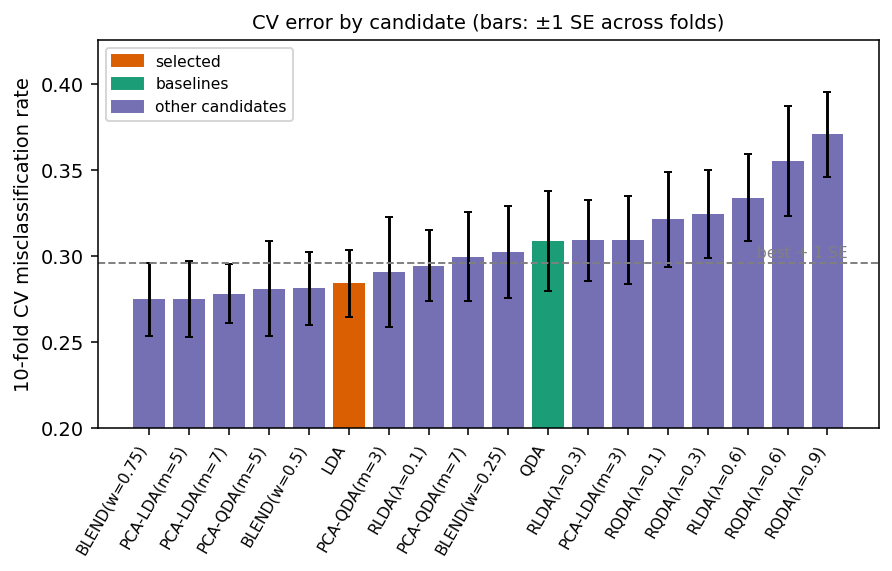

##### Table: candidates and mandatory baselines

| Candidate | CV error | SE |
| --- | --- | --- |
| BLEND(w=0.75) | 0.275 | 0.021 |
| PCA-LDA(m=5) | 0.275 | 0.022 |
| PCA-LDA(m=7) | 0.278 | 0.017 |
| PCA-QDA(m=5) | 0.281 | 0.028 |
| BLEND(w=0.5) | 0.281 | 0.021 |
| LDA ★ | 0.284 | 0.019 |
| PCA-QDA(m=3) | 0.291 | 0.032 |
| RLDA(λ=0.1) | 0.294 | 0.021 |
| PCA-QDA(m=7) | 0.300 | 0.026 |
| QDA | 0.309 | 0.023 |

m = PCA components (standardized inputs); λ = shrinkage / regularization; w = LDA weight in the blend; ★ = selected.

##### Model-fitting results

Best CV error: **BLEND(w=0.75)**, 0.275 (SE 0.021). The selected model by the one-SE rule (simplest candidate within one SE of the best) is **plain LDA**: no PCA components, no regularization, and no blend weight; CV error 0.284 (SE 0.019). Final fit on all 323 training rows; test misclassification rate **0.266** (binomial SE 0.037); test confusion matrix (rows observed, columns predicted): [[77, 14], [23, 25]]. Reference test error for plain LDA 0.266, plain QDA 0.266 (reported only; not used for selection).

##### Methods, findings, and limitations

Candidates: LDA and QDA; shrinkage LDA (3 values); regularized QDA (4 values); PCA with 3/5/7 components followed by LDA or QDA; and LDA-QDA probability blends with weights 0.25/0.5/0.75. Tuning used 10-fold CV with identical folds for all candidates. Many candidates fall within one SE of the best (CV 0.275 to 0.291), so the data cannot separate them; the simple, stable LDA is selected. QDA (CV 0.309) and strongly regularized variants are worse, which suggests the class covariance matrices are not different enough to repay QDA's extra variance with 323 training rows. The estimated prediction error is about 27%, so roughly one in four patients is misclassified, and the majority class makes up about 65% of the data, so the gain over always predicting no chd is modest.

**Limitations.** Small test set (only 139 rows, SE 0.037); the 18-candidate search has some selection optimism; LDA/QDA assume Gaussian predictors, but several predictors are skewed and one is binary; classification uses the 0.5 probability threshold, which treats both error types alike.

### Skill file (`SKILL.md`, 3,316 bytes)

```
---
name: lda-qda-report
description: Explicit-invocation-only guide for an LDA/QDA classification analysis with a one-page report. Use ONLY when the user names this skill.
disable-model-invocation: true
---

# LDA/QDA analysis and one-page report

Load only when the user explicitly invokes this skill. The user supplies the dataset, the response, and the predictors. Never assume names, sizes, or results.

## Scope
All classifiers must be LDA, QDA, or a blend of their class probabilities. Allowed extras: regularized LDA/QDA, PCA embedding before the classifier, and a blend weight `w` in [0,1]: `p = w*p_LDA + (1-w)*p_QDA`. No other model families. Compare candidates by misclassification rate.

## Protocol
1. Report the random seed; set it once, up front.
2. Check the data: missing values, constant columns, class counts, and whether every class has more observations than predictors (QDA needs this). Encode categorical predictors numerically as instructed by the user.
3. Reserve a test set (stratified by class, about 25-30%) BEFORE any modelling. Do not touch it until step 7.
4. Build stratified K-fold CV folds (K=5 or 10) on the training data only. Use the SAME folds for every candidate.
5. Candidates: plain LDA and plain QDA (mandatory baselines), plus any extensions you consider useful, such as a regularization grid, PCA with several numbers of components, or a blend weight grid. Keep the grid small to limit selection bias.
6. Any preprocessing (scaling, PCA) is estimated on the training part of each fold only. Compute the CV error and its standard error across folds for every candidate. Select the best candidate; prefer the simpler model when it is within one standard error of the best.
7. Refit the selected model with its preprocessing on all training observations. Evaluate it ONCE on the reserved test set. Report test error with a binomial standard error and a confusion matrix. Never revise the model after seeing test results.

## Report: at most ONE printed page, clearly readable
Output a single self-contained page (HTML or PDF) with these parts:
- **Title and setup**: sample sizes (train/test), number of predictors, classes with counts, seed.
- **Figure** (one, legible axes and labels): CV misclassification rate for the candidate models with error bars of one standard error, selected model highlighted.
- **Table**: candidates with their settings, CV error, SE, and a rank or selection mark. A second small table for the test confusion matrix is optional.
- **Numerical model-fitting results**: for the selected model, report class priors, the fitted settings (components, regularization, blend weight), the CV error, and the final test error with SE.
- **Brief text** (under 200 words): candidate models, the CV procedure, the selected model and why, the estimated prediction error, main findings, and limitations such as small samples, unstable covariance estimates, Gaussian and equal-covariance assumptions, selection optimism, and test-set noise.

Keep fonts at least 9 pt and verify the page count when printed. If the report exceeds one page, shorten it rather than shrinking the type.

## Style
Plain statistical language, no dataset-specific assumptions, and numbers to 3 significant digits. State clearly which numbers come from CV and which from the test set.
```

### How explicit invocation was enabled

**File size:** 3,316 bytes, under the 5,000-byte limit. **Invocation:** the front matter sets `disable-model-invocation: true`, and the file is kept outside any automatically loaded skills folder, so it is never loaded unless it is attached or named in a request. **Prompt used:**

```
Use the attached skill file "lda-qda-report" (SKILL.md) to analyze a dataset.
Dataset: saheart.csv. Response: chd (coronary heart disease). Predictors: all nine
other columns, with famhist coded 1 = Absent and 2 = Present. Seek the best
predictive performance within the LDA/QDA methods the skill allows, including
ordinary LDA and QDA as comparisons. Use random seed 2026. Reserve a test set first,
use the same CV folds for every candidate, and produce the one-page report.
```